# TO DO:

# Mystery Lead Brick Config Imaging

## Load the MuonDataFrame Objects

```python
from MuDataFrame import *
import copy

r1,r2 = 470, 484
r3, r4 = 513,524
path = "processed_data/run{}.csv"
lead_files = [path.format(i) for i in range(r1,r2+1)] + [path.format(i) for i in range(r3,r4+1)]

mdfo_c = [] #collection of objects

for file in lead_files:
    mdfo_c.append(MuDataFrame(file)) #Muon Data Frame Object for Lead

mdf_list = [i.events_df for i in mdfo_c]
mdf_lead = mdfo_c[0].getMergedMDF(mdf_list)

mdfo_lead = copy.copy(mdfo_c[0])
mdfo_lead.events_df = mdf_lead

mdfo_lead.longDataMode()

mdf_lead = mdfo_lead.events_df
mdfo_lead.og_df = mdf_lead.copy()
mdfo_lead.show()
```

[output not shown]

2700000 rows × 73 columns

```python
from MuDataFrame import *

mdfo_calib = MuDataFrame("processed_data/calibration_data.csv")

#mdfo_calib.longDataMode()

mdf_calib = mdfo_calib.events_df
mdfo_calib.og_df = mdf_calib.copy()
mdfo_calib.show()
```

|  | Unnamed: 0 | Unnamed: 0.1 | Unnamed: 0.1.1 | event_num | event_time | deadtime | l1hit | l2hit | l3hit | l4hit | ... | theta_y2 | z_angle | SmallCounter | Run_Num | xx | yy | speed | index | xx1 | yy1 |
| --- | --- | --- | --- | --- | --- | --- | --- | --- | --- | --- | --- | --- | --- | --- | --- | --- | --- | --- | --- | --- | --- |
| 0 | 0 | 0 | 0.0 | 0 | 0 | 0 | 1.0 | 1.0 | 1.0 | 1.0 | ... | -75.200711 | 6.371653 | NaN | 408 | 8.402778 | 8.285486 | 11.076032 | NaN | 8.330769 | 7.792308 |
| 1 | 1 | 1 | 1.0 | 1 | 94137 | 0 | 1.0 | 1.0 | 1.0 | 1.0 | ... | -13.905355 | 11.086497 | NaN | 408 | -8.389304 | 29.851975 | 0.386791 | NaN | -8.076923 | 28.484615 |
| 2 | 2 | 2 | 2.0 | 2 | 259967 | 0 | 1.0 | 1.0 | 1.0 | 1.0 | ... | 136.431052 | 6.613531 | NaN | 408 | -4.230215 | -16.106861 | 0.277034 | NaN | -6.169231 | -16.838462 |
| 3 | 3 | 3 | 3.0 | 3 | 540068 | 0 | 1.0 | 1.0 | 1.0 | 1.0 | ... | 136.369656 | 11.331981 | NaN | 408 | -29.130160 | -7.886501 | 0.449059 | NaN | -30.076923 | -7.976923 |
| 4 | 4 | 4 | 4.0 | 4 | 650077 | 0 | 1.0 | 1.0 | 1.0 | 1.0 | ... | -138.183939 | 15.394396 | NaN | 408 | 12.760181 | -29.695749 | 0.223868 | NaN | 12.830769 | -30.823077 |
| ... | ... | ... | ... | ... | ... | ... | ... | ... | ... | ... | ... | ... | ... | ... | ... | ... | ... | ... | ... | ... | ... |
| 1999995 | 1999995 | 1999995 | NaN | 1999995 | 630008348673 | 0 | 1.0 | 1.0 | 1.0 | 1.0 | ... | -41.380285 | 13.218939 | NaN | 445 | 28.791795 | -2.510153 | 0.201915 | 99995.0 | 35.707692 | -4.407692 |
| 1999996 | 1999996 | 1999996 | NaN | 1999996 | 630008608684 | 0 | 1.0 | 1.0 | 1.0 | 1.0 | ... | 125.123871 | 8.974938 | NaN | 445 | 13.189311 | -10.555556 | 0.271806 | 99996.0 | 16.615385 | -11.546154 |
| 1999997 | 1999997 | 1999997 | NaN | 1999997 | 630009188778 | 0 | 1.0 | 1.0 | 1.0 | 0.0 | ... | NaN | NaN | NaN | 445 | 7.572244 | NaN | NaN | 99997.0 | 10.684615 | NaN |
| 1999998 | 1999998 | 1999998 | NaN | 1999998 | 630009558770 | 0 | 1.0 | 1.0 | 1.0 | 1.0 | ... | 67.544962 | NaN | NaN | 445 | NaN | -23.824668 | NaN | 99998.0 | NaN | -29.246154 |
| 1999999 | 1999999 | 1999999 | NaN | 1999999 | 630009828830 | 0 | 1.0 | 0.0 | 0.0 | 0.0 | ... | NaN | NaN | NaN | 445 | NaN | NaN | NaN | 99999.0 | NaN | NaN |

2000000 rows × 74 columns

## Muon Rate Plots

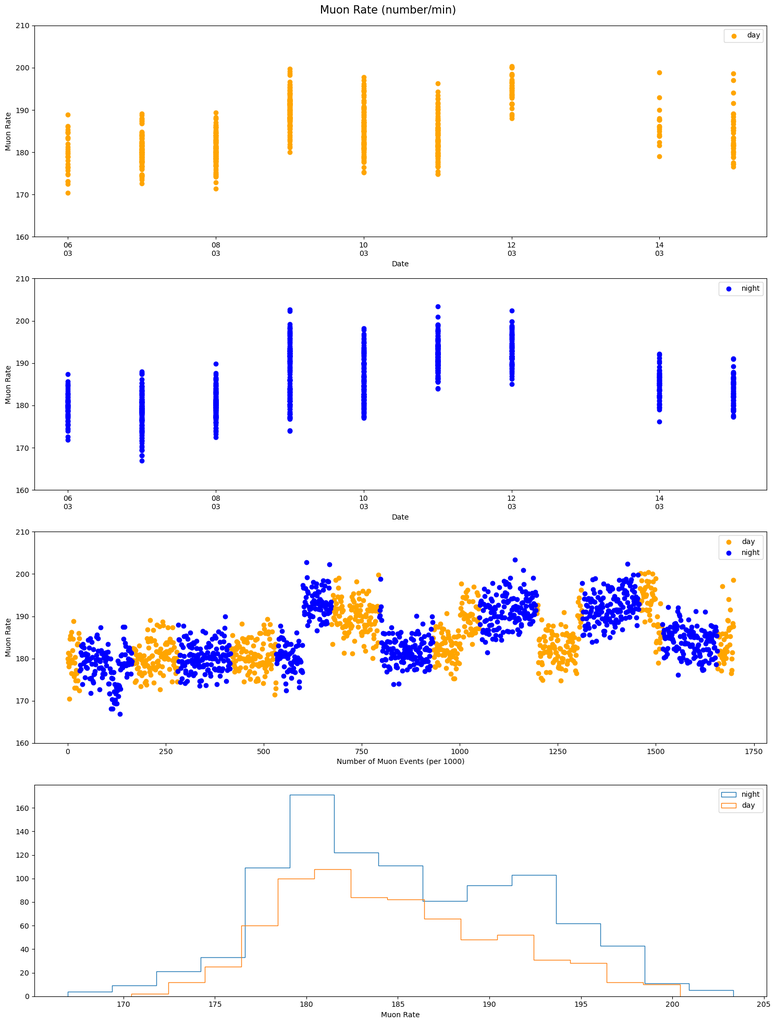

```python
import matplotlib.dates as mdates

ms2min = 1.6666666666666667*10**(-8)
fidelity = 15*ms2min

def cm_to_inch(value):
    return value/2.54

def getMuonRate(mdfo, mu_num_thresh_hold,pdf=False):
    ms2min = 1.6666666666666667*10**(-8)
    times = mdfo.get("time")*ms2min
    mu_num = mdfo.get("event_num")
    dates = [i.split(" ")[0] for i in mdfo.get("event_time")]
    dates = [datetime.datetime.strptime(d,'%Y-%m-%d').date() for d in dates]
    colors = ['red' if x == "day" else 'blue' for x in mdfo.get("time_of_day")]
    time_arr = []
    color = []
    date_str = []

    for i in range(len(mu_num)):
        if mu_num[i] % mu_num_thresh_hold == 0:
            time_arr.append(times[i])
            color.append(colors[i])
            date_str.append(dates[i])

    time_diff = np.diff(np.array(time_arr))
    mu_rate = np.array(mu_num_thresh_hold / time_diff)
    xvals = np.array([i for i in range(len(mu_rate))])

    day = np.array(color) == "red"
    night = np.array(color) == "blue"

    fig, axes = plt.subplots(nrows=4, ncols=1,figsize=(15,20))
    plt.suptitle("Muon Rate (number/min)\n",fontsize = 15)
    ax0, ax1, ax2, ax3 = axes.flatten()

    date_str = np.array(date_str)
    dates_day = date_str[day[:]][1:]
    dates_night = date_str[night[:]]

    dates_day = mdates.date2num(dates_day)    # Convert to maplotlib format
    dates_night = mdates.date2num(dates_night)
    hfmt = mdates.DateFormatter('%d\n%m')
    ax0.scatter(dates_day, mu_rate[day[1:]], color='orange', label="day")
    ax0.legend()
    ax0.set_xlabel("Date")
    ax0.set_ylabel("Muon Rate")
    ax0.set_ylim([160,210])
    ax0.xaxis.set_major_formatter(hfmt)
    ax0.tick_params(labelbottom=True)

    ax1.scatter(dates_night, mu_rate[night[1:]],color='blue', label="night")
    ax1.legend()
    ax1.set_xlabel("Date")
    ax1.set_ylabel("Muon Rate")
    ax1.set_ylim([160,210])
    ax1.xaxis.set_major_formatter(hfmt)
    ax1.tick_params(labelbottom=True)

    ax2.scatter(xvals[day[1:]], mu_rate[day[1:]],color='orange', label="day")
    ax2.scatter(xvals[night[1:]], mu_rate[night[1:]],color='blue', label="night")
    ax2.legend()
    ax2.set_xlabel("Number of Muon Events (per 1000)")
    ax2.set_ylabel("Muon Rate")
    ax2.set_ylim([160,210])


    ax3.hist(mu_rate[night[1:]],label="night",histtype="step",bins=15)
    ax3.hist(mu_rate[day[1:]],label="day",histtype="step",bins=15)
    ax3.set_xlabel("Muon Rate")
    plt.legend()

    fig.tight_layout()
    if not pdf:
        plt.savefig("muon_rate.png")
        plt.show()
    else:
        return fig

mdfo_lead.reload()
#mdfo_lead.keep4by4Events()
getMuonRate(mdfo_lead,1000)
```

Weather info:

"https://www.wunderground.com/history/weekly/us/tx/lubbock/KLBB/date/2021-3-7"

## Analysis Function Definitions

```python
import copy

def getSameShapeDataSets(mdfo1, mdfo2):
    mdfo1 =  copy.copy(mdfo1)
    mdfo2 = copy.copy(mdfo2)
    s1 = len(mdfo1.events_df.index)
    s2 = len(mdfo2.events_df.index)
    s = min(s1,s2)
    mdfo1.events_df =  mdfo1.events_df.iloc[:s]
    mdfo2.events_df =  mdfo2.events_df.iloc[:s]
    return mdfo1, mdfo2

def getSameSizeData(mdfo1, mdfo2, data_term):
    mdfo1, mdfo2 = getSameShapeDataSets(mdfo1, mdfo2)
    return mdfo1.get(data_term), mdfo2.get(data_term)

def getRatioPlot( xviews, yviews, axes=[-30,30], bins=(15,15),title="Data"):
    xx_lead, xx_calib = xviews
    yy_lead, yy_calib = yviews
    ranges = (axes,axes)
    h1, xedges, yedges = np.histogram2d(xx_lead, yy_lead, bins=bins, range=ranges)
    h2, xedges, yedges = np.histogram2d(xx_calib, yy_calib, bins=bins, range=ranges)
    h = h1 / h2
 #   h[h >= 1.15] = 1.15
 #   h[h <= 0.8] = 0.8
    fig, ax = plt.subplots(1)
    pc = ax.pcolorfast(xedges, yedges, h.T)
    plt.title("Reco Z plane XY View Ratio ({})".format(title),fontsize=15)
    plt.xlabel("X (cm)")
    plt.ylabel("Y (cm)")
    plt.colorbar(pc)
    plt.show()
```

```python
def getXatZPlane_diffTDC(x1, x2, zplane, dsep):
    x = (zplane / dsep) * (
        getPhysicalUnitsFromDiffTDC(x1) -
        getPhysicalUnitsFromDiffTDC(x2)) + getPhysicalUnitsFromDiffTDC(x1)
    return x

def getPhysicalUnitsFromDiffTDC(tdc):
    return (55 / 130) * tdc

#mdfo_lead.reload()

#xx_lead = getXatZPlane_diffTDC(mdfo_lead.get("diffL1"), mdfo_lead.get("diffL3"), 42,165)
#yy_lead = getXatZPlane_diffTDC(mdfo_lead.get("diffL2"), mdfo_lead.get("diffL4"), 42,165)

#mdfo_lead.events_df["xx1"] = xx_lead
#mdfo_lead.events_df["yy1"] = yy_lead
```

# Tomogram Generations

Only looking at 4/4 events at different binning.

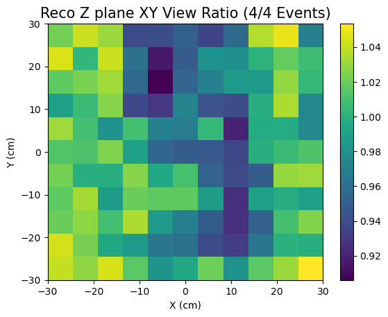

```python
mdfo_lead.reload()
mdfo_lead.keep4by4Events()

mdfo_calib.reload()
mdfo_calib.keep4by4Events()

xx_lead, xx_calib = getSameSizeData(mdfo_lead, mdfo_calib, "xx1")
yy_lead, yy_calib = getSameSizeData(mdfo_lead, mdfo_calib, "yy1")

getRatioPlot([xx_lead,xx_calib],[yy_lead,yy_calib],bins=(11,11),axes=[-30,30],title="4/4 Events")
```

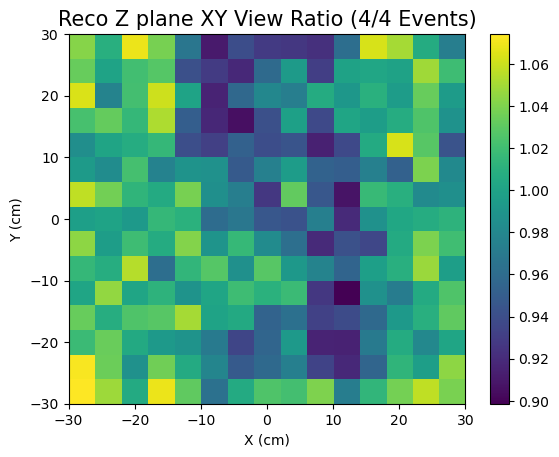

```python
mdfo_lead.reload()
mdfo_lead.keep4by4Events()

mdfo_calib.reload()
mdfo_calib.keep4by4Events()

xx_lead, xx_calib = getSameSizeData(mdfo_lead, mdfo_calib, "xx1")
yy_lead, yy_calib = getSameSizeData(mdfo_lead, mdfo_calib, "yy1")

getRatioPlot([xx_lead,xx_calib],[yy_lead,yy_calib],bins=(15,15),axes=[-30,30],title="4/4 Events")
```

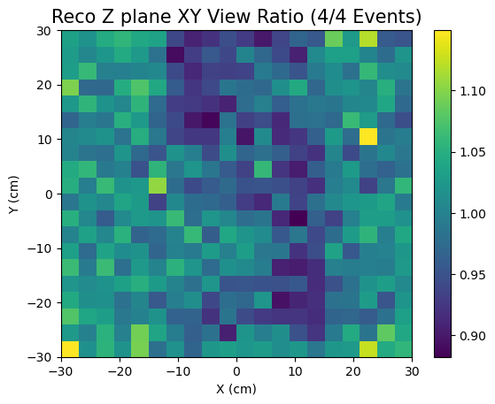

```python
mdfo_lead.reload()
mdfo_lead.keep4by4Events()

mdfo_calib.reload()
mdfo_calib.keep4by4Events()

xx_lead, xx_calib = getSameSizeData(mdfo_lead, mdfo_calib, "xx1")
yy_lead, yy_calib = getSameSizeData(mdfo_lead, mdfo_calib, "yy1")

getRatioPlot([xx_lead,xx_calib],[yy_lead,yy_calib],bins=(20,20),axes=[-30,30],title="4/4 Events")
```

# The effect of 2 hits in Ch0 scaler.

We should check if the crisp definition of 11 peaks change or not with/without these events.

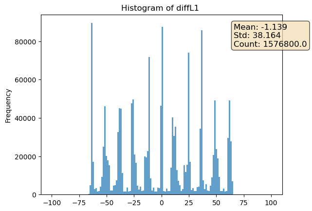

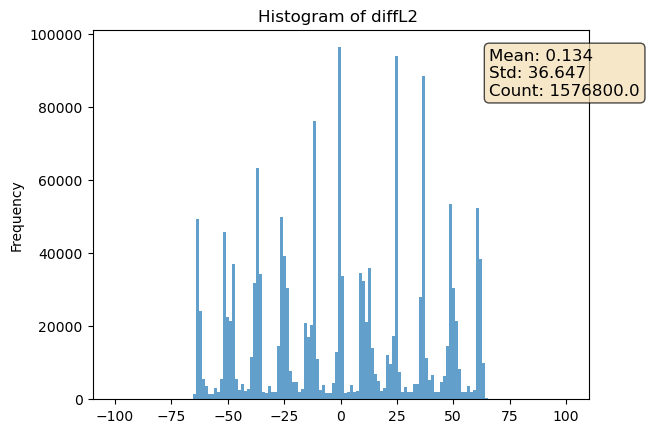

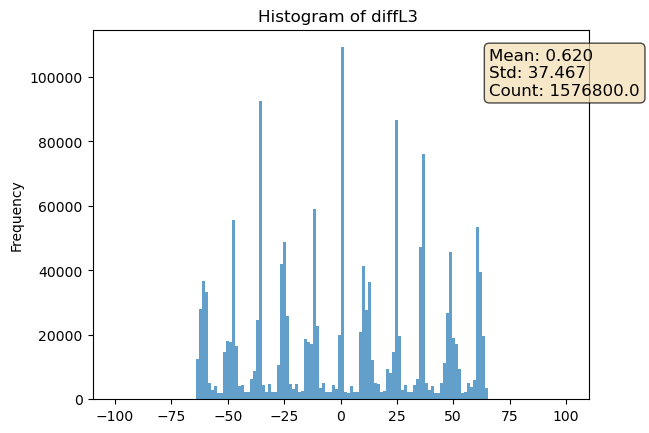

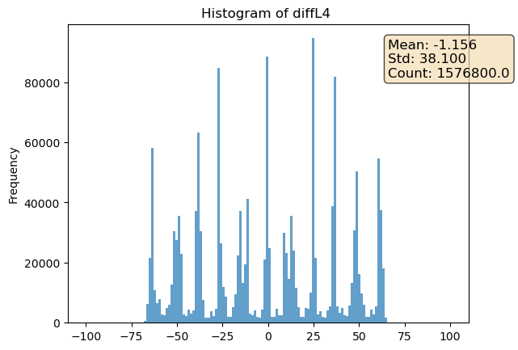

```python
mdfo_lead.reload()
mdfo_lead.keep4by4Events()

mdfo_lead.getHistogram("diffL1",nbins=150,range=(-100,100))
mdfo_lead.getHistogram("diffL2",nbins=150,range=(-100,100))
mdfo_lead.getHistogram("diffL3",nbins=150,range=(-100,100))
mdfo_lead.getHistogram("diffL4",nbins=150,range=(-100,100))
```

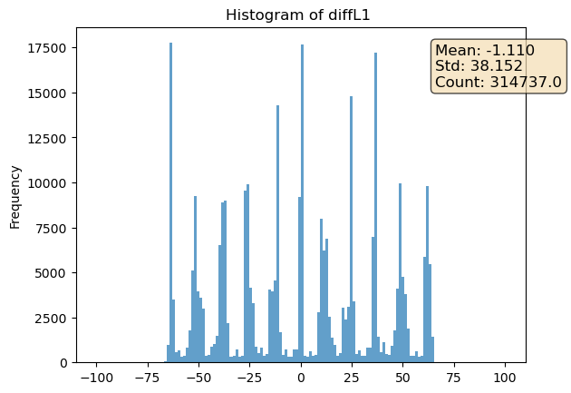

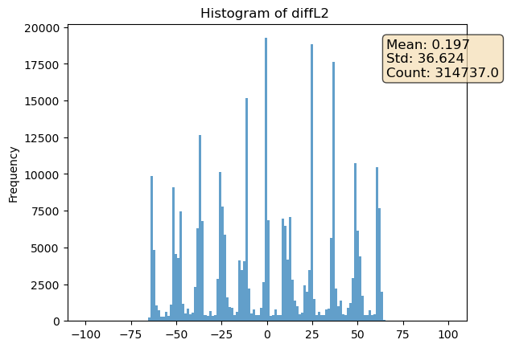

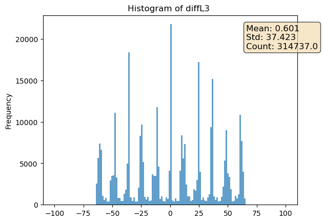

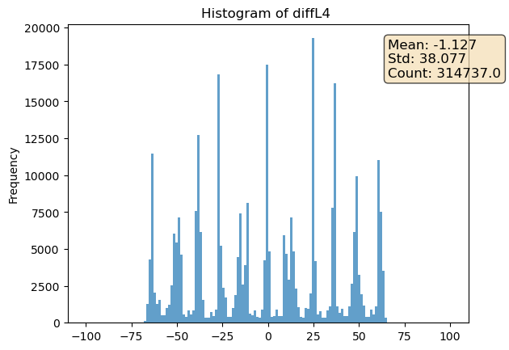

```python
mdfo_lead.reload()
mdfo_lead.keep4by4Events()
mdfo_lead.keepEvents("SCh0", 2, "==")


mdfo_lead.getHistogram("diffL1",nbins=150,range=(-100,100))
mdfo_lead.getHistogram("diffL2",nbins=150,range=(-100,100))
mdfo_lead.getHistogram("diffL3",nbins=150,range=(-100,100))
mdfo_lead.getHistogram("diffL4",nbins=150,range=(-100,100))
```

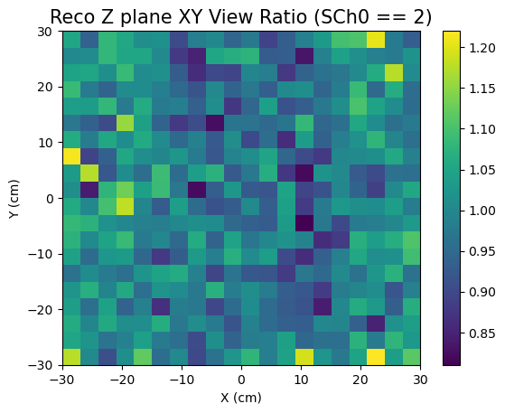

```python
mdfo_lead.reload()
mdfo_lead.keep4by4Events()
mdfo_lead.keepEvents("SCh0", 2, "==")

mdfo_calib.reload()
mdfo_calib.keep4by4Events()

xx_lead, xx_calib = getSameSizeData(mdfo_lead, mdfo_calib, "xx1")
yy_lead, yy_calib = getSameSizeData(mdfo_lead, mdfo_calib, "yy1")

getRatioPlot([xx_lead,xx_calib],[yy_lead,yy_calib],bins=(20,20),axes=[-30,30],title="SCh0 == 2")
```

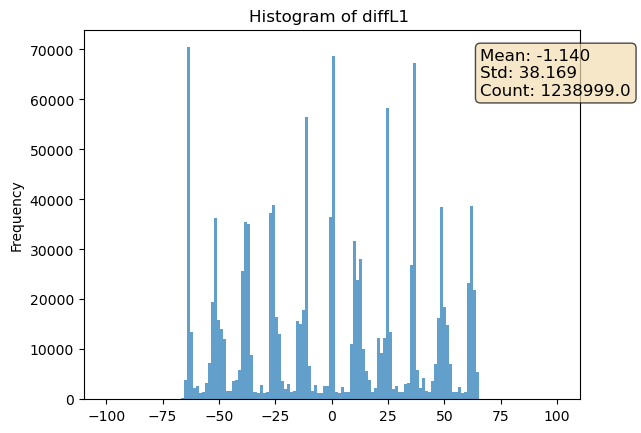

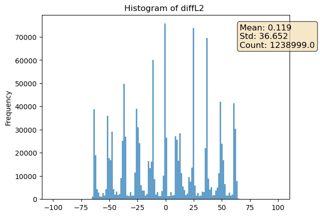

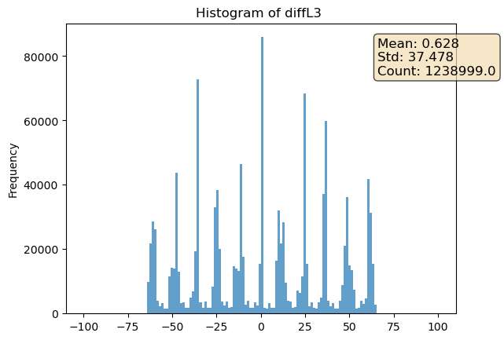

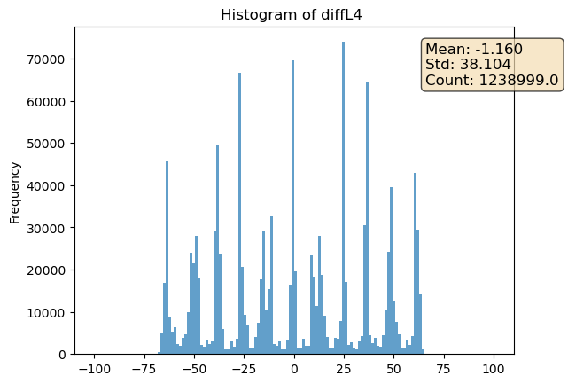

```python
mdfo_lead.reload()
mdfo_lead.keep4by4Events()
mdfo_lead.keepEvents("SCh0", 1, "==")


mdfo_lead.getHistogram("diffL1",nbins=150,range=(-100,100))
mdfo_lead.getHistogram("diffL2",nbins=150,range=(-100,100))
mdfo_lead.getHistogram("diffL3",nbins=150,range=(-100,100))
mdfo_lead.getHistogram("diffL4",nbins=150,range=(-100,100))
```

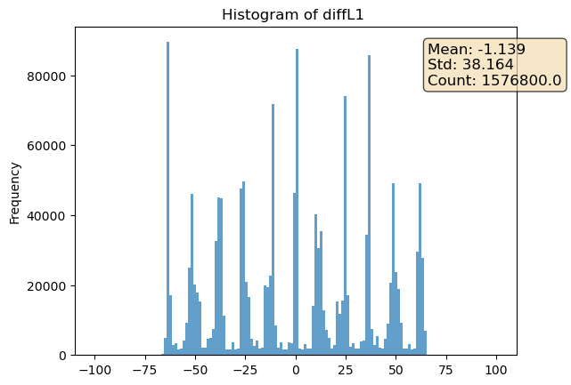

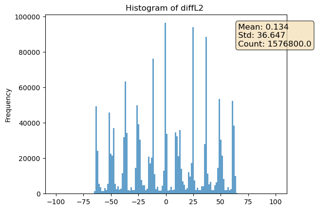

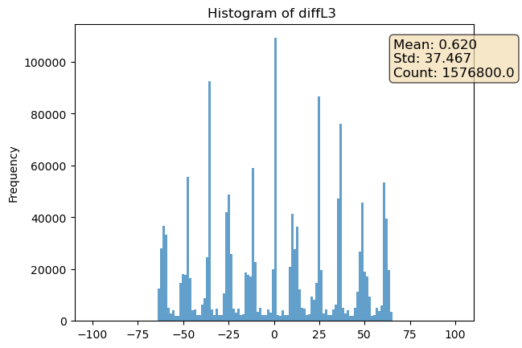

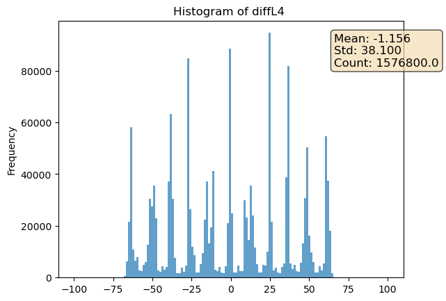

```python
mdfo_lead.reload()
mdfo_lead.keep4by4Events()

mdfo_lead.getHistogram("diffL1",nbins=150,range=(-100,100))
mdfo_lead.getHistogram("diffL2",nbins=150,range=(-100,100))
mdfo_lead.getHistogram("diffL3",nbins=150,range=(-100,100))
mdfo_lead.getHistogram("diffL4",nbins=150,range=(-100,100))
```

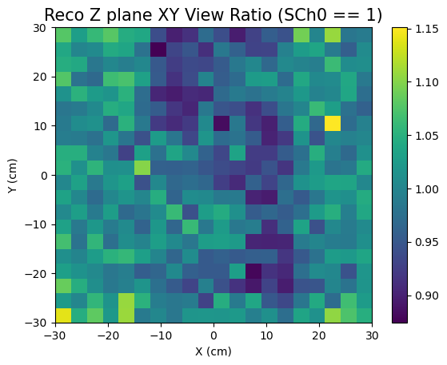

```python
mdfo_lead.reload()
mdfo_lead.keep4by4Events()
mdfo_lead.keepEvents("SCh0", 1, "==")

mdfo_calib.reload()
mdfo_calib.keep4by4Events()

xx_lead, xx_calib = getSameSizeData(mdfo_lead, mdfo_calib, "xx1")
yy_lead, yy_calib = getSameSizeData(mdfo_lead, mdfo_calib, "yy1")

getRatioPlot([xx_lead,xx_calib],[yy_lead,yy_calib],bins=(20,20),axes=[-30,30],title="SCh0 == 1")
```

**SCh0 == 1** seems to be better than **SCh0 == 2**. None of these affect the resolution of the individual peaks.

# Noise in Tray 3

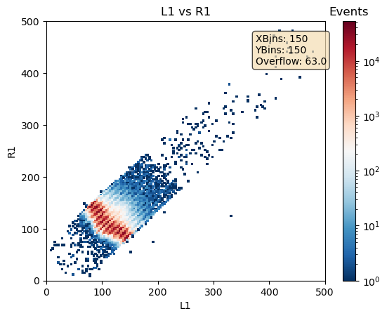

```python
mdfo_lead.reload()
mdfo_lead.keep4by4Events()
mdfo_lead.get2DHistogram(mdf_lead.get("L1"),
                         mdf_lead.get("R1"),
                         "L1 vs R1",
                         "L1","R1",
                         0,500,0,500)
```

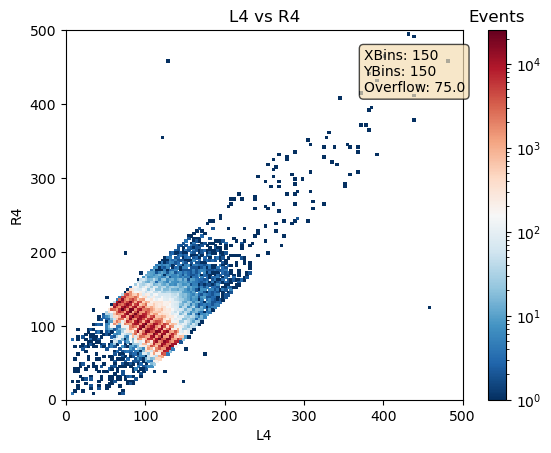

```python
mdfo_lead.reload()
mdfo_lead.keep4by4Events()
mdfo_lead.get2DHistogram(mdf_lead.get("L4"),
                         mdf_lead.get("R4"),
                         "L4 vs R4",
                         "L4","R4",
                         0,500,0,500)
```

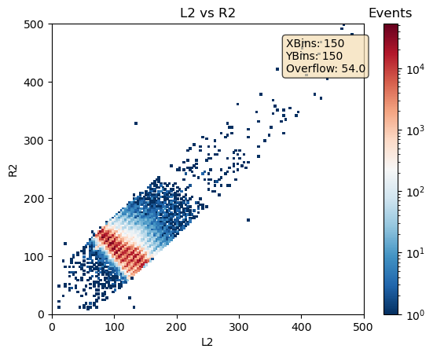

```python
mdfo_lead.reload()
mdfo_lead.keep4by4Events()
mdfo_lead.get2DHistogram(mdf_lead.get("L2"),
                         mdf_lead.get("R2"),
                         "L2 vs R2",
                         "L2","R2",
                         0,500,0,500)
```

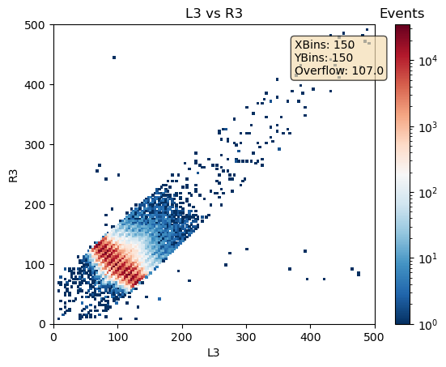

```python
mdfo_lead.reload()
mdfo_lead.keep4by4Events()
mdfo_lead.get2DHistogram(mdf_lead.get("L3"),
                         mdf_lead.get("R3"),
                         "L3 vs R3",
                         "L3","R3",
                         0,500,0,500)
```

Tray does have a higher overflow compared to all the other trays for the same bounds. There are also more hits that are "L" shaped compared to the other trays.